# Homework Assignment 1

Zejie Gao

2023-01-23

1. The dataset trees contains measurements of Girth (tree diameter) in inches, Height in feet, and Volume of timber (in cubic feet) of a sample of 31 felled black cherry trees. The following commands can be used to read the data into R.

```r
require(datasets)
head(trees)
```

```
##   Girth Height Volume
## 1   8.3     70   10.3
## 2   8.6     65   10.3
## 3   8.8     63   10.2
## 4  10.5     72   16.4
## 5  10.7     81   18.8
## 6  10.8     83   19.7
```

1. Briefly describe the data set trees, i.e., how many observations (rows) and how many variables (columns) are there in the data set? What are the variable names?

```r
nrow(trees)
```

```
## [1] 31
```

```r
ncol(trees)
```

```
## [1] 3
```

```r
ls(trees)
```

```
## [1] "Girth"  "Height" "Volume"
```

```r
# There are 31 rows and 3 column in the data set, with three variables named "Girth","Height", and  "Volume"
```

2. Use the pairs function to construct a scatter plot matrix of the logarithms of Girth, Height and Volume.

```r
library(tidyverse)
```

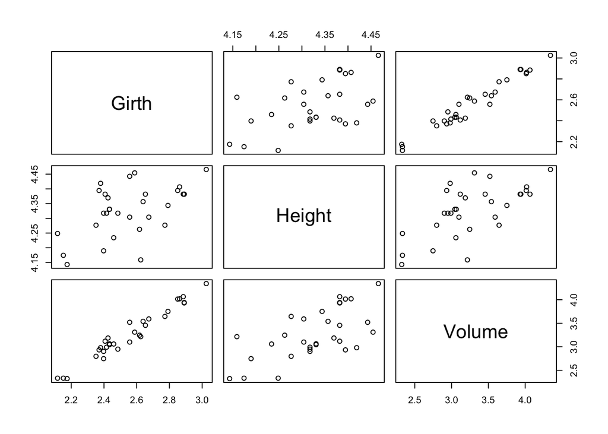

```r
log_trees <- trees |>
  mutate(Girth = log(Girth)) |>
  mutate(Height = log(Height))|>
  mutate(Volume = log(Volume))
pairs(log_trees)
```

(c) Use the cor function to determine the correlation matrix for the three (logged) variables.

```r
cor(log_trees)
```

```
##            Girth    Height    Volume
## Girth  1.0000000 0.5301949 0.9766649
## Height 0.5301949 1.0000000 0.6486377
## Volume 0.9766649 0.6486377 1.0000000
```

4. Are there missing values?

```r
is.na(log_trees)
```

```
##       Girth Height Volume
##  [1,] FALSE  FALSE  FALSE
##  [2,] FALSE  FALSE  FALSE
##  [3,] FALSE  FALSE  FALSE
##  [4,] FALSE  FALSE  FALSE
##  [5,] FALSE  FALSE  FALSE
##  [6,] FALSE  FALSE  FALSE
##  [7,] FALSE  FALSE  FALSE
##  [8,] FALSE  FALSE  FALSE
##  [9,] FALSE  FALSE  FALSE
## [10,] FALSE  FALSE  FALSE
## [11,] FALSE  FALSE  FALSE
## [12,] FALSE  FALSE  FALSE
## [13,] FALSE  FALSE  FALSE
## [14,] FALSE  FALSE  FALSE
```

[output cut: 17 more lines]

```r
sum(is.na(log_trees))
```

```
## [1] 0
```

```r
# No, there is no missing values
```

5. Use the lm function in R to fit the multiple regression model: log(Volumei) = β0 + β1 log(Girthi) + β2 log(Heighti) + εi and print out the summary of the model fit.

```r
fit <- lm(Volume ~ Girth + Height, data = log_trees)
fit
```

```
##
## Call:
## lm(formula = Volume ~ Girth + Height, data = log_trees)
##
## Coefficients:
## (Intercept)        Girth       Height
##      -6.632        1.983        1.117
```

```r
y <- log_trees$Volume
x1 <- log_trees$Girth
x2 <- log_trees$Height
R.2 <- 1 - sum((fit$residuals^2))/ (sum((y - mean(y))^2))
R.2
```

```
## [1] 0.9776784
```

```r
summary(fit)
```

```
##
## Call:
## lm(formula = Volume ~ Girth + Height, data = log_trees)
##
## Residuals:
##       Min        1Q    Median        3Q       Max
## -0.168561 -0.048488  0.002431  0.063637  0.129223
##
## Coefficients:
##             Estimate Std. Error t value Pr(>|t|)
## (Intercept) -6.63162    0.79979  -8.292 5.06e-09 ***
## Girth        1.98265    0.07501  26.432  < 2e-16 ***
## Height       1.11712    0.20444   5.464 7.81e-06 ***
## ---
## Signif. codes:  0 '***' 0.001 '**' 0.01 '*' 0.05 '.' 0.1 ' ' 1
##
## Residual standard error: 0.08139 on 28 degrees of freedom
## Multiple R-squared:  0.9777, Adjusted R-squared:  0.9761
## F-statistic: 613.2 on 2 and 28 DF,  p-value: < 2.2e-16
```

```r
# Estimation of the lm: log(Volumei) = -6.63 + 1.98 log(Girthi) + 1.12 log(Heighti) + εi
# Since R^2 (0.9777 or 0.978 on the summary) is very close to 1, the model better fits the data.
```

6. Create the design matrix (i.e., the matrix of predictor variables), X, for the model in (e), and verify that the least squares coefficient estimates in the summary output are given by the least squares formula: βˆ = (X^T X)<sup>(−1)X</sup>T y.

```r
v1 <- log_trees$Girth
v2 <- log_trees$Height
X <- cbind(rep(1, times=nrow(log_trees)),v1,v2) # create a matrix by combining vectors column-wise
y <- matrix(log_trees$Volume)
βˆ <- solve(t(X)%*%(X))%*%(t(X)%*%(y))
βˆ
```

```
##         [,1]
##    -6.631617
## v1  1.982650
## v2  1.117123
```

```r
# The βˆ matrix match the output I got in (e)
```

7. Compute the predicted response values from the fitted regression model, the residuals, and an estimate of the error variance Var(ε) = σ^2.

```r
y_hat <- X%*%βˆ
y_hat
```

```
##           [,1]
##  [1,] 2.310270
##  [2,] 2.297879
##  [3,] 2.308547
##  [4,] 2.807900
##  [5,] 2.976888
##  [6,] 3.022580
##  [7,] 2.802931
##  [8,] 2.945736
##  [9,] 3.035777
## [10,] 2.981461
## [11,] 3.057130
## [12,] 3.031349
## [13,] 3.031349
## [14,] 2.974906
```

[output cut: 17 more lines]

```r
Res <- fit$residuals
sigma2.hat <- sum(Res^2) / fit$df.residual
sigma2.hat
```

```
## [1] 0.006623692
```

```r
SSR <- sum(fit$residuals^2)
SSR
```

```
## [1] 0.1854634
```

```r
# SSR = 0.1855
# Var(εi) = 0.006624
```

2. Consider the simple linear regression model: yi = β0 + β1xi + εi
1. Assume β0 = 0. What is the interpretation of this assumption? What is the implication on the regression line? What does the regression line plot look like?

```r
# The assumption represent that the yi will have a high likelihood to be zero when xi equals to zero.
# It implicate the y intercept of linear regression model is zero.
# The regression line start from coordinate (0,0).
```

2. Derive the LS estimate of β1 when β0 = 0.

```r
# β1 = sum((y-mean(y))*(x-mean(x)))/sum((x-mean(x))ˆ2)
# β1 does not influenced by β0 value
```

3. How can we introduce this assumption within the lm function?

```r
# lm(y ~ x-1, data = dataset)
# Based on the assumption β0 = 0, β0 from lm function can be deleted.Then, the lm function will become yi = β1xi + εi
```

4. For the same model, assume β1 = 0. What is the interpretation of this assumption? What is the implication on the regression line? What does the regression line plot look like?

```r
# The assumption represent that the value of yi does not affected by the value of xi. The predictor x1 is not significant when explaining yi.
# It implicate the linear regression model wasn't able to find a linear relationship between the yi and x1.
# The plot will only have a horizontal line which is y = constant value (β0 + εi) or so called the mean of y.
```

5. Derive the LS estimate of β0 when β1 = 0.

```r
# β0 = mean(y)
```

6. How can we introduce this assumption within the lm function?

```r
# lm(y ~ 1, data = dataset)
# Based on the assumption β1 = 0, β1 part from lm function can be deleted.Then, the lm function will become  yi = β0 +  εi.
```

3. Consider the simple linear regression model: yi = β0 + β1xi + εi
1. Use the LS estimation general result βˆ = (XT X)−1XT y to find the explicit estimates for β0 and β1.

```r
# on the pdf
```

[output not shown]

[output not shown]

2. Show that the LS estimates βˆ0 and βˆ1 are unbiased estimates for β0 and β1 respectively.

```r
# on the pdf
```

[output not shown]

[output not shown]